KDD: Comprensión lectora en México (PLANEA 2018) 1. Selección de datos Se seleccionó la base de datos planea06_2018_alumnos.parquet, correspondiente a la aplicación de PLANEA 2018 en 6º de primaria. Esta base contiene 104,973 registros (alumnos) y 632 variables, y fue obtenida del acervo público del INEE/MEJOREDU.

Las variables de interés se organizan en tres grupos:

Identificación y contexto: NOM_ENT (entidad federativa), SERV (tipo de escuela), SEXO, W_FSTUWT (peso de muestreo). Puntajes de comprensión lectora: PV1LYC, PV2LYC, PV3LYC, PV4LYC, PV5LYC (los 5 valores plausibles de Lenguaje y Comunicación). Variables de diseño muestral: estratos y pesos replicados. La comprensión lectora se utiliza como proxy del desarrollo cognitivo, ya que la base no contiene variables directas sobre el currículo artístico.

```r
# 1. CARGAR DATOS ---------------------------------
library(arrow)
library(dplyr)
# Pega aquí tu ruta real, con / en lugar de \
ruta <- "C:\\Users\\Xuser\\Downloads\\planea06_2018_alumnos.parquet"

# Verificación rápida antes de leer
print(file.info(ruta)$size)
```

```
## [1] 49669938
```

```r
print(readBin(ruta, "raw", n = 4))
```

```
## [1] 50 41 52 31
```

```r
# Leer desactivando mmap (evita errores en Windows)
datos <- arrow::read_parquet(ruta, mmap = FALSE)
```

3. Transformación Se construyó una variable única de comprensión lectora promediando los 5 valores plausibles: datos$lectura <- rowMeans(datos[, c(“PV1LYC”,“PV2LYC”,“PV3LYC”, “PV4LYC”,“PV5LYC”)], na.rm = TRUE)
4. Minería de datos Se realizó un análisis estadístico descriptivo y comparativo:

```r
datos$lectura <- rowMeans(datos[, c("PV1LYC","PV2LYC","PV3LYC",
                                    "PV4LYC","PV5LYC")], na.rm = TRUE)

# 3. PANORAMA NACIONAL -----------------------------
# Filtrar filas con lectura y peso válidos
sub <- datos[!is.na(datos$lectura) & !is.na(datos$W_FSTUWT), ]

# Promedio nacional ponderado
promedio_nacional <- weighted.mean(sub$lectura, sub$W_FSTUWT)
cat("Promedio nacional:", round(promedio_nacional, 1), "\n")
```

```
## Promedio nacional: 500.6
```

```r
# 4. Entidad Federativa (ponderado)
por_entidad <- datos %>%
  group_by(NOM_ENT) %>%
  summarise(lectura_prom = weighted.mean(lectura, W_FSTUWT, na.rm = TRUE),
            alumnos = n()) %>%
  arrange(desc(lectura_prom))

print(por_entidad)
```

```
## # A tibble: 32 × 3
##    NOM_ENT          lectura_prom alumnos
##    <fct>                   <dbl>   <int>
##  1 CIUDAD DE MÉXICO         541.    4826
##  2 AGUASCALIENTES           519.    3937
##  3 COLIMA                   519.    2714
##  4 QUERÉTARO                518.    3762
##  5 NUEVO LEÓN               517.    4516
##  6 MÉXICO                   517.    6218
##  7 COAHUILA                 516.    3605
##  8 QUINTANA ROO             516.    3281
##  9 SONORA                   514.    3693
## 10 JALISCO                  513.    4187
## # ℹ 22 more rows
```

```r
# 5. Tipo de Escuela
por_servicio <- datos %>%
  group_by(SERV) %>%
  summarise(lectura_prom = weighted.mean(lectura, W_FSTUWT, na.rm = TRUE),
            alumnos = n()) %>%
  arrange(desc(lectura_prom))

print(por_servicio)
```

```
## # A tibble: 4 × 3
##   SERV            lectura_prom alumnos
##   <fct>                  <dbl>   <int>
## 1 Privada                 597.   12025
## 2 General Pública         495.   86564
## 3 Comunitaria             446.     990
## 4 Indígena                428.    5394
```

```r
# 6. Sexo
por_sexo <- datos %>%
  group_by(SEXO) %>%
  summarise(lectura_prom = weighted.mean(lectura, W_FSTUWT, na.rm = TRUE),
            alumnos = n())

print(por_sexo)
```

```
## # A tibble: 3 × 3
##   SEXO   lectura_prom alumnos
##   <fct>         <dbl>   <int>
## 1 Hombre         486.   52328
## 2 Mujer          515.   52632
## 3 <NA>           532.      13
```

Promedio nacional ponderado de comprensión lectora. Promedios por entidad federativa, ordenados de mayor a menor.

Comparación por tipo de escuela (Privada, General Pública, Comunitaria, Indígena). Comparación por sexo.

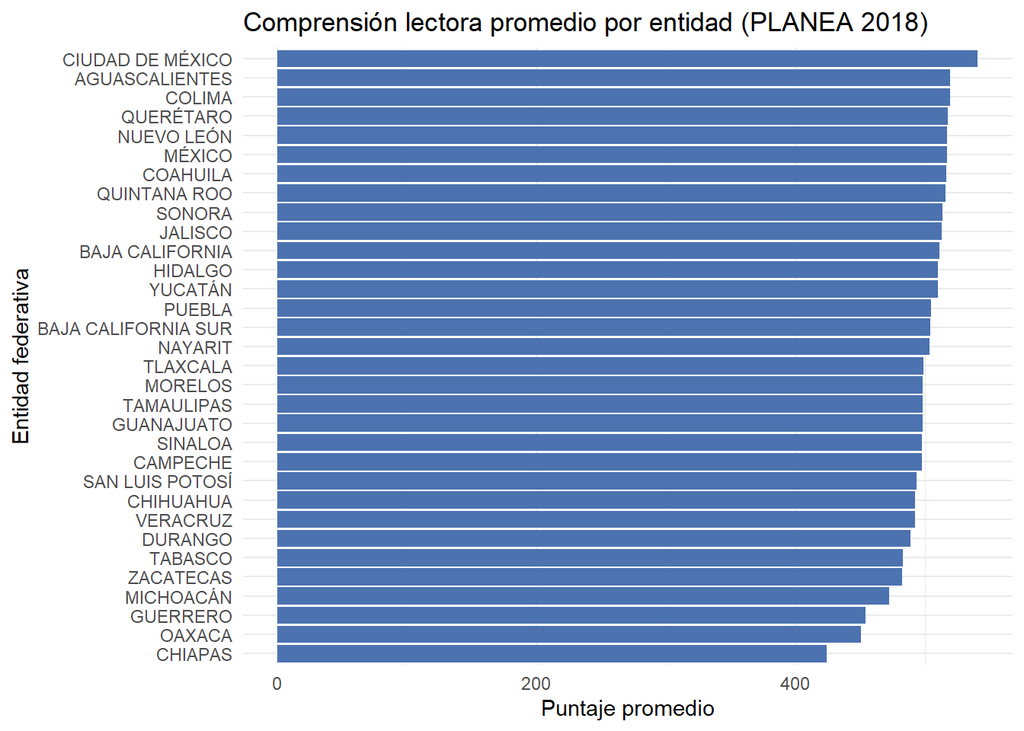

```r
# 7. GRÁFICO: PROMEDIO POR ENTIDAD -----------------
library(ggplot2)

ggplot(por_entidad, aes(x = reorder(NOM_ENT, lectura_prom), y = lectura_prom)) +
  geom_col(fill = "#4C72B0") +
  coord_flip() +
  labs(title = "Comprensión lectora promedio por entidad (PLANEA 2018)",
       x = "Entidad federativa", y = "Puntaje promedio") +
  theme_minimal()
```

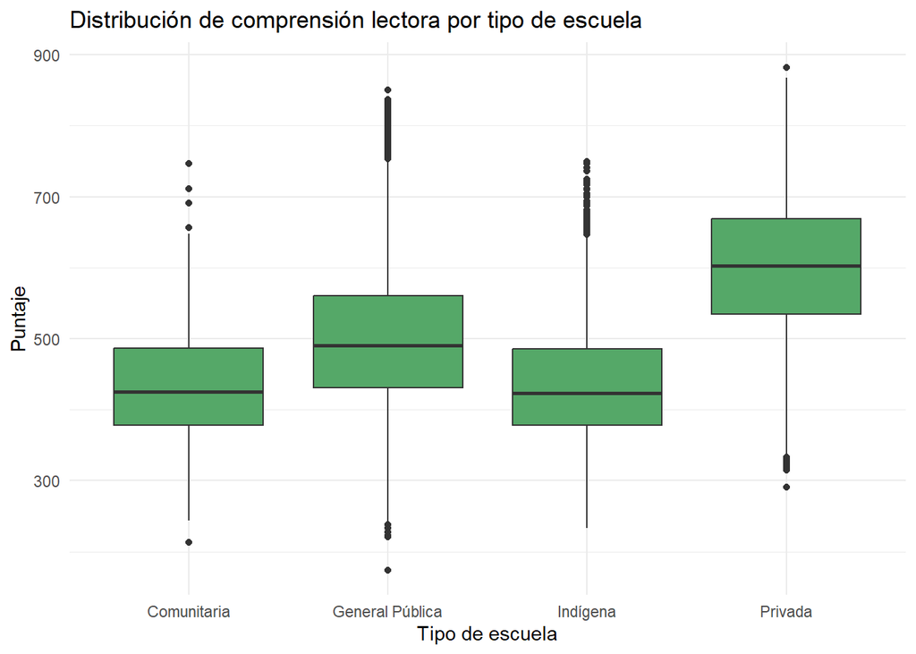

```r
# 8. GRÁFICO: DISTRIBUCIÓN POR TIPO DE ESCUELA -----
ggplot(datos, aes(x = SERV, y = lectura)) +
  geom_boxplot(fill = "#55A868") +
  labs(title = "Distribución de comprensión lectora por tipo de escuela",
       x = "Tipo de escuela", y = "Puntaje") +
  theme_minimal()
```

Conclusión Existe una asociación clara entre el tipo de escuela (relacionado con el contexto socioeconómico y la ubicación) y el nivel de comprensión lectora. Esto evidencia que el desarrollo cognitivo, medido a través de la lectura, no se distribuye de manera equitativa en el país. Este hallazgo conecta directamente con el tema del rezago educativo y las condiciones diferenciadas de las escuelas en México.